# Assignment2

Whytne Stevens

9/8/2020

# Assignment 2

Continuing with the variables and data used in Assignment 1, I am now looking at the distributions and proportions of these variables, which are listed below:

Sex (SEX) (categorical)

Standard Occupational Classification (SOCP) (categorical)

English ability (ENG) (categorical)

Language other than English spoken at home (LANX) (categorical)

Income (PINCP) (continuous)

Work hours per week (WKHP) (continuous)

Income-to-poverty ratio (POVPIP) (continuous)

```r
library(ggplot2)
library(tidycensus)
library(tidyverse)
library(ggthemes)
```

```r
person_vars_2018 <- pums_variables %>%
  distinct(year, survey, var_code,
           var_label, data_type, level) %>%
  filter(level == "person", year == 2018, survey == "acs1")
```

```r
area_vars_2018 <- load_variables(2018, "acs1")
```

```r
dallas_county <- c("02301", "02302", "02303", "02304", "02308", "02317", "02318", "02319", "02320", "02321", "02322")
```

```r
person_data <- get_pums(variables = c("PUMA",
                                      "RAC1P",
                                      "SEX",
                                      "SOCP",
                                      "LANX",
                                      "ENG",
                                      "PINCP",
                                      "WKHP",
                                      "POVPIP"),
                        state = "TX",
                        year = 2018,
                        survey = "acs1",
                        recode = TRUE) %>%
  mutate(SOCP = as.numeric(SOCP)) %>%
  filter(PUMA == dallas_county,
         PINCP > 0,
         SOCP > 0,
         WKHP > 0,
         POVPIP > 0) %>%
  select(RAC1P_label, SEX_label, SOCP_label, ENG_label, LANX_label, PINCP, WKHP, POVPIP)
```

```r
person_data <- read_csv("assignmentonedata.csv")
```

# Distributions of my Continuous Variables

For each of my continuous variables (total person’s income, hours worked per week, and income to poverty ratio) below, I calculated the sample men, median, standard deviation, and interquartile ranges. I also calculated the 95-percent confidence interval for the mean of each of these variables and created a histogram to show that distribution

## Total person’s income

```r
PINCP_summary <- summary(person_data$PINCP)

PINCP_summary
```

```
##    Min. 1st Qu.  Median    Mean 3rd Qu.    Max.
##     100   20100   37000   48131   60000  468200
```

```r
paste("The sample mean for total person's income is",
      prettyNum(mean(person_data$PINCP), digits = 1), "USD.")
```

```
## [1] "The sample mean for total person's income is 48131 USD."
```

```r
paste("The sample median for total person's income is",
      prettyNum(median(person_data$PINCP), digits = 1), "USD.")
```

```
## [1] "The sample median for total person's income is 37000 USD."
```

```r
paste("The sample standard deviation for total person's income is",
      prettyNum(sd(person_data$PINCP), digits = 1), "USD.")
```

```
## [1] "The sample standard deviation for total person's income is 49152 USD."
```

```r
paste("The sample interquartile range for total person's income is",
      quantile(person_data$PINCP)["25%"], "to", quantile(person_data$PINCP)["75%"], "USD.")
```

```
## [1] "The sample interquartile range for total person's income is 20100 to 60000 USD."
```

```r
conf_int_pincp <- t.test(person_data$PINCP)

conf_int_pincp
```

```
##
##  One Sample t-test
##
## data:  person_data$PINCP
## t = 22.394, df = 522, p-value < 2.2e-16
## alternative hypothesis: true mean is not equal to 0
## 95 percent confidence interval:
##  43908.85 52353.37
## sample estimates:
## mean of x
##  48131.11
```

```r
paste("The 95-percent confidence interval for total person's income is",
      prettyNum(conf_int_pincp$conf.int[1], digits = 1), "to",
      prettyNum(conf_int_pincp$conf.int[2], digits = 1), "USD.")
```

```
## [1] "The 95-percent confidence interval for total person's income is 43909 to 52353 USD."
```

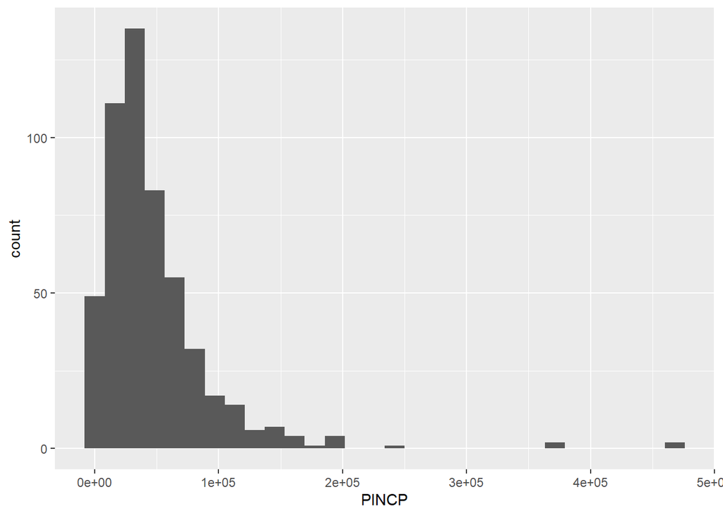

```r
hist_pincp <-ggplot(person_data, aes(x = PINCP)) +
  geom_histogram()

hist_pincp
```

[figure not shown]

```r
hist_pincp +
  theme_solarized_2() +
  scale_x_continuous(name = "Total person's income (USD)") +
  scale_y_continuous(name = "Number of people in sample") +
  annotate("text", x = 490000, y = 150, size = 3,
           label = paste("Population mean (95% confidence):",
                         prettyNum(conf_int_pincp$conf.int[1], digits = 1),
                         "to",
                         prettyNum(conf_int_pincp$conf.int[2], digits = 1),
                         "USD.",
                         "\nSample mean:",
                         prettyNum(mean(PINCP_summary), digits = 1), "USD.",
                         "\nSample median:",
                         prettyNum(median(PINCP_summary), digits = 1), "USD.",
                         "\nSample standard deviation:",
                         prettyNum(sd(PINCP_summary), digits = 1), "USD.",
                         "\nSample interquartile range:",
                         prettyNum(quantile(PINCP_summary)["25%"], digits = 1),
                         "to",
                         prettyNum(quantile(PINCP_summary)["75%"], digits = 1),
                         "USD."),
           hjust = 1, vjust = 1)
```

## Hours worked per week

```r
WKHP_summary <- summary(person_data$WKHP)

WKHP_summary
```

```
##    Min. 1st Qu.  Median    Mean 3rd Qu.    Max.
##    1.00   40.00   40.00   39.61   42.00   99.00
```

```r
paste("The sample mean for hours worked per week is",
      prettyNum(mean(person_data$WKHP), digits = 1), "hours per week.")
```

```
## [1] "The sample mean for hours worked per week is 40 hours per week."
```

```r
paste("The sample median for hours worked per week is",
      prettyNum(median(person_data$WKHP), digits = 1), "hours per week.")
```

```
## [1] "The sample median for hours worked per week is 40 hours per week."
```

```r
paste("The sample standard deviation for hours worked per week is",
      prettyNum(sd(person_data$WKHP), digits = 1), "hours per week.")
```

```
## [1] "The sample standard deviation for hours worked per week is 12 hours per week."
```

```r
paste("The sample interquartile range for hours worked per week is",
      quantile(person_data$WKHP)["25%"], "to", quantile(person_data$WKHP)["75%"], "hours per week.")
```

```
## [1] "The sample interquartile range for hours worked per week is 40 to 42 hours per week."
```

```r
conf_int_wkhp <- t.test(person_data$WKHP)

conf_int_wkhp
```

```
##
##  One Sample t-test
##
## data:  person_data$WKHP
## t = 75.885, df = 522, p-value < 2.2e-16
## alternative hypothesis: true mean is not equal to 0
## 95 percent confidence interval:
##  38.58451 40.63537
## sample estimates:
## mean of x
##  39.60994
```

```r
paste("The 95-percent confidence interval for hours worked per week  is",
      prettyNum(conf_int_wkhp$conf.int[1], digits = 1), "to",
      prettyNum(conf_int_wkhp$conf.int[2], digits = 1), "hours per week.")
```

```
## [1] "The 95-percent confidence interval for hours worked per week  is 39 to 41 hours per week."
```

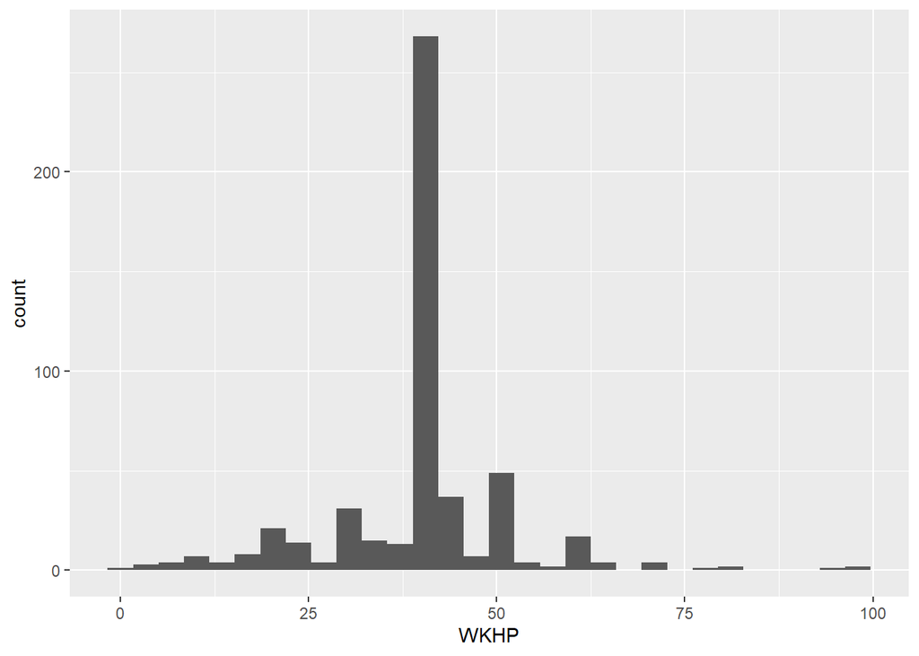

```r
hist_wkhp <- ggplot(person_data, aes(x = WKHP)) +
  geom_histogram()
hist_wkhp
```

[figure not shown]

```r
hist_wkhp +
  theme_solarized_2() +
  scale_x_continuous(name = "Hours worked per week") +
  scale_y_continuous(name = "Number of people in sample") +
  annotate("text", x = 100, y = 275, size = 3,
           label = paste("Population mean (95% confidence):",
                         prettyNum(conf_int_wkhp$conf.int[1], digits = 1),
                         "to",
                         prettyNum(conf_int_wkhp$conf.int[2], digits = 1),
                         "hours per week.",
                         "\nSample mean:",
                         prettyNum(mean(WKHP_summary), digits = 1), "hours per week.",
                         "\nSample median:",
                         prettyNum(median(WKHP_summary), digits = 1), "hours per week.",
                         "\nSample standard deviation:",
                         prettyNum(sd(WKHP_summary), digits = 1), "hours per week.",
                         "\nSample interquartile range:",
                         prettyNum(quantile(WKHP_summary)["25%"], digits = 1),
                         "to",
                         prettyNum(quantile(WKHP_summary)["75%"], digits = 1),
                         "hours per week."),
           hjust = 1, vjust = 1)
```

## Income to poverty ratio

```r
POVPIP_summary <- summary(person_data$POVPIP)

POVPIP_summary
```

```
##    Min. 1st Qu.  Median    Mean 3rd Qu.    Max.
##    11.0   232.5   390.0   356.8   501.0   501.0
```

```r
paste("The sample mean for income to poverty ratio is",
      prettyNum(mean(person_data$POVPIP), digits = 1), ".")
```

```
## [1] "The sample mean for income to poverty ratio is 357 ."
```

```r
paste("The sample median for income to poverty ratio is",
      prettyNum(median(person_data$POVPIP), digits = 1), ".")
```

```
## [1] "The sample median for income to poverty ratio is 390 ."
```

```r
paste("The sample standard deviation for income to poverty ratio is",
      prettyNum(sd(person_data$POVPIP), digits = 1), ".")
```

```
## [1] "The sample standard deviation for income to poverty ratio is 146 ."
```

```r
paste("The sample interquartile range for income to poverty ratio is",
      quantile(person_data$POVPIP)["25%"], "to", quantile(person_data$POVPIP)["75%"], ".")
```

```
## [1] "The sample interquartile range for income to poverty ratio is 232.5 to 501 ."
```

```r
conf_int_povpip <- t.test(person_data$POVPIP)

conf_int_povpip
```

```
##
##  One Sample t-test
##
## data:  person_data$POVPIP
## t = 55.719, df = 522, p-value < 2.2e-16
## alternative hypothesis: true mean is not equal to 0
## 95 percent confidence interval:
##  344.1991 369.3573
## sample estimates:
## mean of x
##  356.7782
```

```r
paste("The 95-percent confidence interval for income to poverty ratio is",
      prettyNum(conf_int_povpip$conf.int[1], digits = 1), "to",
      prettyNum(conf_int_povpip$conf.int[2], digits = 1), ".")
```

```
## [1] "The 95-percent confidence interval for income to poverty ratio is 344 to 369 ."
```

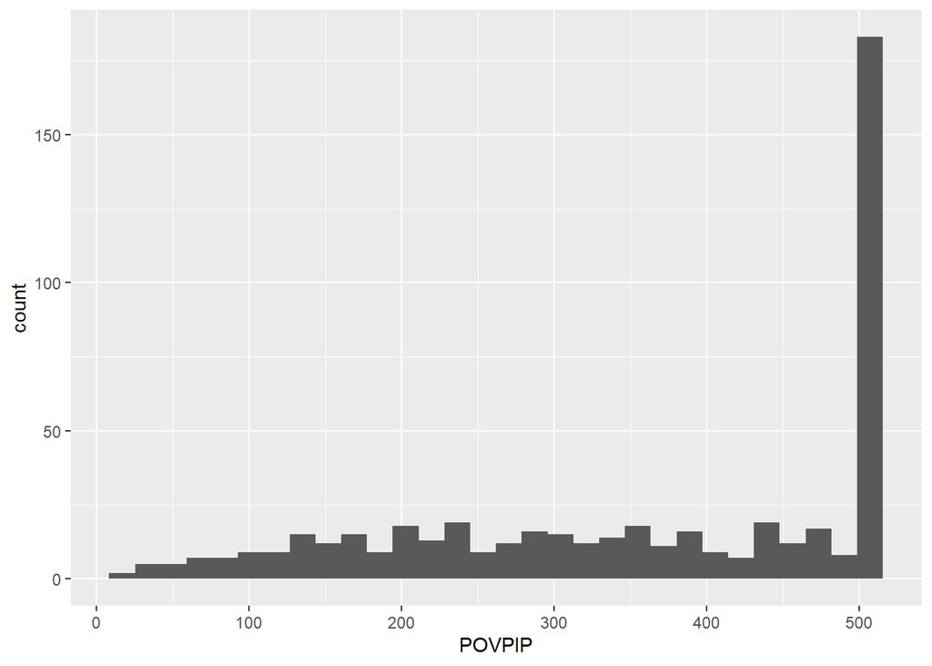

```r
hist_povpip <- ggplot(person_data, aes(x = POVPIP)) +
  geom_histogram()
hist_povpip
```

[figure not shown]

```r
hist_povpip +
  theme_solarized_2() +
  scale_x_continuous(name = "Income to poverty ratio") +
  scale_y_continuous(name = "Number of people in sample") +
  annotate("text", x = 100, y = 200, size = 3,
           label = paste("Population mean (95% confidence):",
                         prettyNum(conf_int_povpip$conf.int[1], digits = 1),
                         "to",
                         prettyNum(conf_int_povpip$conf.int[2], digits = 1),
                         "hours per week.",
                         "\nSample mean:",
                         prettyNum(mean(POVPIP_summary), digits = 1), ".",
                         "\nSample median:",
                         prettyNum(median(POVPIP_summary), digits = 1), ".",
                         "\nSample standard deviation:",
                         prettyNum(sd(POVPIP_summary), digits = 1), ".",
                         "\nSample interquartile range:",
                         prettyNum(quantile(POVPIP_summary)["25%"], digits = 1),
                         "to",
                         prettyNum(quantile(POVPIP_summary)["75%"], digits = 1),
                         "."),
           hjust = 0, vjust = 1)
```

# Proportions of my Categorial Variables

As for my categorical variables (race, sex, occupation, English language proficiency, and whether or not someone speaks a language besides English at home) below, I calculated the distribution of each by looking at the number observation in each variable category, converted the number of these observations to proportions, and calculated the 95-percent confidence interval for each of these proportions as well.

## Race

```r
unique(person_data$RAC1P_label)
```

```
## [1] "White alone"
## [2] "Black or African American alone"
## [3] "Asian alone"
## [4] "Two or More Races"
## [5] "Some Other Race alone"
## [6] "American Indian alone"
## [7] "American Indian and Alaska Native tribes specified; or American Indian or Alaska Native, not specified and no other races"
## [8] "Native Hawaiian and Other Pacific Islander alone"
```

```r
table(person_data$RAC1P_label)
```

```
##
##                                                                                                     American Indian alone
##                                                                                                                         1
## American Indian and Alaska Native tribes specified; or American Indian or Alaska Native, not specified and no other races
##                                                                                                                         2
##                                                                                                               Asian alone
##                                                                                                                        44
##                                                                                           Black or African American alone
##                                                                                                                       118
##                                                                          Native Hawaiian and Other Pacific Islander alone
##                                                                                                                         2
##                                                                                                     Some Other Race alone
##                                                                                                                        36
##                                                                                                         Two or More Races
##                                                                                                                        13
##                                                                                                               White alone
##                                                                                                                       307
```

```r
knitr::kable(table(person_data$RAC1P_label), caption = "Frequency Counts for RAC1P Variable")
```

Frequency Counts for RAC1P Variable

| Var1 | Freq |
| --- | --- |
| American Indian alone | 1 |
| American Indian and Alaska Native tribes specified; or American Indian or Alaska Native, not specified and no other races | 2 |
| Asian alone | 44 |
| Black or African American alone | 118 |
| Native Hawaiian and Other Pacific Islander alone | 2 |
| Some Other Race alone | 36 |
| Two or More Races | 13 |
| White alone | 307 |

```r
table(person_data$RAC1P_label) / sum(table(person_data$RAC1P_label))
```

```
##
##                                                                                                     American Indian alone
##                                                                                                               0.001912046
## American Indian and Alaska Native tribes specified; or American Indian or Alaska Native, not specified and no other races
##                                                                                                               0.003824092
##                                                                                                               Asian alone
##                                                                                                               0.084130019
##                                                                                           Black or African American alone
##                                                                                                               0.225621415
##                                                                          Native Hawaiian and Other Pacific Islander alone
##                                                                                                               0.003824092
##                                                                                                     Some Other Race alone
##                                                                                                               0.068833652
##                                                                                                         Two or More Races
##                                                                                                               0.024856597
##                                                                                                               White alone
##                                                                                                               0.586998088
```

```r
mean(person_data$RAC1P_label == "Black or African American alone")
```

```
## [1] 0.2256214
```

```r
t.test(person_data$RAC1P_label == "Black or African American alone")
```

```
##
##  One Sample t-test
##
## data:  person_data$RAC1P_label == "Black or African American alone"
## t = 12.332, df = 522, p-value < 2.2e-16
## alternative hypothesis: true mean is not equal to 0
## 95 percent confidence interval:
##  0.1896806 0.2615622
## sample estimates:
## mean of x
## 0.2256214
```

```r
tenures1 <- unique(person_data$RAC1P_label)
tenures1
```

```
## [1] "White alone"
## [2] "Black or African American alone"
## [3] "Asian alone"
## [4] "Two or More Races"
## [5] "Some Other Race alone"
## [6] "American Indian alone"
## [7] "American Indian and Alaska Native tribes specified; or American Indian or Alaska Native, not specified and no other races"
## [8] "Native Hawaiian and Other Pacific Islander alone"
```

```r
white <- t.test(person_data$RAC1P_label == tenures1[1])
black <- t.test(person_data$RAC1P_label == tenures1[2])
asian <- t.test(person_data$RAC1P_label == tenures1[3])
two_or_more_race <-  t.test(person_data$RAC1P_label == tenures1[4])
some_other_race_alone <-  t.test(person_data$RAC1P_label == tenures1[5])
amer_ind_alone <- t.test(person_data$RAC1P_label == tenures1[6])
amer_ind_ala_native_tribes_spec_or_not_spec <-  t.test(person_data$RAC1P_label == tenures1[7])
nat_hawaiian_and_oth_pac_is_alone <-  t.test(person_data$RAC1P_label == tenures1[8])
shares <- tibble(Tenure = c("White alone",
                            "Black or African American alone",
                            "Asian alone",
                            "Two or More Races",
                            "Some Other Race alone",
                            "American Indian alone",
                            "American Indian and Alaska Native tribes specified; or American Indian or Alaska Native, not specified and no other races",
                            "Native Hawaiian and Other Pacific Islander alone"),
                 `Share` = c(white$estimate,
                             black$estimate,
                             asian$estimate,
                             two_or_more_race$estimate,
                             some_other_race_alone$estimate,
                             amer_ind_alone$estimate,
                             amer_ind_ala_native_tribes_spec_or_not_spec$estimate,
                             nat_hawaiian_and_oth_pac_is_alone$estimate),
                 Low = c(white$conf.int[1],
                         black$conf.int[1],
                         asian$conf.int[1],
                         two_or_more_race$conf.int[1],
                         some_other_race_alone$conf.int[1],
                         amer_ind_alone$conf.int[1],
                         amer_ind_ala_native_tribes_spec_or_not_spec$conf.int[1],
                         nat_hawaiian_and_oth_pac_is_alone$conf.int[1]),
                 High = c(white$conf.int[2],
                         black$conf.int[2],
                         asian$conf.int[2],
                         two_or_more_race$conf.int[2],
                         some_other_race_alone$conf.int[2],
                         amer_ind_alone$conf.int[2],
                         amer_ind_ala_native_tribes_spec_or_not_spec$conf.int[2],
                         nat_hawaiian_and_oth_pac_is_alone$conf.int[2]))
knitr::kable(shares, caption = "Proportions and 95-percent confidence intervals for RAC1P variable")
```

Proportions and 95-percent confidence intervals for RAC1P variable

| Tenure | Share | Low | High |
| --- | --- | --- | --- |
| White alone | 0.5869981 | 0.5446615 | 0.6293346 |
| Black or African American alone | 0.2256214 | 0.1896806 | 0.2615622 |
| Asian alone | 0.0841300 | 0.0602622 | 0.1079979 |
| Two or More Races | 0.0248566 | 0.0114698 | 0.0382434 |
| Some Other Race alone | 0.0688337 | 0.0470648 | 0.0906025 |
| American Indian alone | 0.0019120 | -0.0018442 | 0.0056683 |
| American Indian and Alaska Native tribes specified; or American Indian or Alaska Native, not specified and no other races | 0.0038241 | -0.0014830 | 0.0091311 |
| Native Hawaiian and Other Pacific Islander alone | 0.0038241 | -0.0014830 | 0.0091311 |

[figure not shown]

```r
ggplot(shares, aes(x = Tenure, y = Share, ymin = Low, ymax = High)) +
  geom_bar(stat = "identity") +
  geom_errorbar(width = 0.5) +
  theme_solarized_2() +
  scale_x_discrete(labels = c("White alone",
                            "Black or \nAfrican American alone",
                            "Asian alone",
                            "Two or \nMore Races",
                            "Some Other \nRace alone",
                            "American Indian \nalone",
                            "American Indian and Alaska Native tribes specified; or American Indian or Alaska Native, not specified and no other races",
                            "Native Hawaiian and Other Pacific Islander alone")) +
  scale_y_continuous(name = "Share of population (error bars represent\n 95-percent confidence interval)",
                     breaks = c(0, 0.1, 0.2, 0.3, 0.4, 0.5, 0.6, 0.7, 0.8),
                     labels = c("0", "10%", "20%", "30%", "40%", "50%", "60%", "70%", "80%"))
```

## Sex

```r
unique(person_data$SEX_label)
```

```
## [1] "Female" "Male"
```

```r
table(person_data$SEX_label)
```

```
##
## Female   Male
##    262    261
```

```r
knitr::kable(table(person_data$SEX_label), caption = "Frequency Counts for SEX Variable")
```

Frequency Counts for SEX Variable

| Var1 | Freq |
| --- | --- |
| Female | 262 |
| Male | 261 |

```r
table(person_data$SEX_label) / sum(table(person_data$SEX_label))
```

```
##
##   Female     Male
## 0.500956 0.499044
```

```r
mean(person_data$SEX_label == "Female")
```

```
## [1] 0.500956
```

```r
t.test(person_data$SEX_label == "Female")
```

```
##
##  One Sample t-test
##
## data:  person_data$SEX_label == "Female"
## t = 22.891, df = 522, p-value < 2.2e-16
## alternative hypothesis: true mean is not equal to 0
## 95 percent confidence interval:
##  0.4579638 0.5439483
## sample estimates:
## mean of x
##  0.500956
```

```r
tenures2 <- unique(person_data$SEX_label)
tenures2
```

```
## [1] "Female" "Male"
```

```r
female <- t.test(person_data$SEX_label == tenures2[1])
male <- t.test(person_data$SEX_label == tenures2[2])
shares <- tibble(Tenure = c("Female",
                            "Male"),
                 `Share` = c(female$estimate,
                             male$estimate),
                 Low = c(female$conf.int[1],
                         male$conf.int[1]),
                 High = c(female$conf.int[2],
                          male$conf.int[2]))
knitr::kable(shares, caption = "Proportions and 95-percent confidence intervals for SEX variable")
```

Proportions and 95-percent confidence intervals for SEX variable

| Tenure | Share | Low | High |
| --- | --- | --- | --- |
| Female | 0.500956 | 0.4579638 | 0.5439483 |
| Male | 0.499044 | 0.4560517 | 0.5420362 |

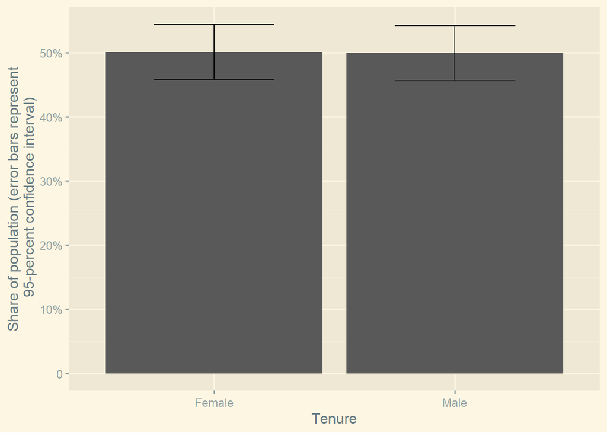

```r
ggplot(shares, aes(x = Tenure, y = Share, ymin = Low, ymax = High)) +
  geom_bar(stat = "identity") +
  geom_errorbar(width = 0.5) +
  theme_solarized_2() +
  scale_x_discrete(labels = c("Female",
                            "Male")) +
  scale_y_continuous(name = "Share of population (error bars represent\n 95-percent confidence interval)",
                     breaks = c(0, 0.1, 0.2, 0.3, 0.4, 0.5),
                     labels = c("0", "10%", "20%", "30%", "40%", "50%"))
```

## Occupation

```r
unique(person_data$SOCP_label)
```

```
##   [1] "FIN-Accountants And Auditors"
##   [2] "TRN-Stockers And Order Fillers"
##   [3] "OFF-Bookkeeping, Accounting, And Auditing Clerks"
##   [4] "TRN-Cleaners Of Vehicles And Equipment"
##   [5] "EDU-Teaching Assistants"
##   [6] "SAL-Real Estate Brokers And Sales Agents"
##   [7] "CON-Construction Equipment Operators"
##   [8] "BUS-Management Analysts"
##   [9] "TRN-Bus Drivers, Transit And Intercity"
##  [10] "CON-Construction Laborers"
##  [11] "PRS-Manicurists and Pedicurists"
##  [12] "PRT-Correctional Officers And Jailers"
##  [13] "PRS-Hairdressers, Hairstylists, And Cosmetologists"
##  [14] "RPR-Precision Instrument And Equipment Repairers"
##  [15] "MGR-Sales Managers"
```

[output cut: 156 more lines]

```r
table(person_data$SOCP_label)
```

```
##
##                                                       BUS-Business Operations Specialists, All Other
##                                                                                                    4
##                                       BUS-Claims Adjusters, Appraisers, Examiners, And Investigators
##                                                                                                    3
##                                                                          BUS-Human Resources Workers
##                                                                                                    3
##                                                                                     BUS-Logisticians
##                                                                                                    1
##                                                                              BUS-Management Analysts
##                                                                                                    4
##                                                                   BUS-Project Management Specialists
##                                                                                                    3
##                                   BUS-Purchasing Agents, Except Wholesale, Retail, And Farm Products
##                                                                                                    1
##                                    CLN-First-Line Supervisors Of Housekeeping And Janitorial Workers
##                                                                                                    1
##                                                                  CLN-Maids And Housekeeping Cleaners
##                                                                                                    6
##                                                                      CMM-Computer Network Architects
##                                                                                                    2
##                                                                             CMM-Computer Programmers
##                                                                                                    5
##                                                                     CMM-Computer Support Specialists
##                                                                                                    4
##                                                                        CMM-Computer Systems Analysts
##                                                                                                    2
##                                                      CMM-Network And Computer Systems Administrators
##                                                                                                    1
##                                                                              CMM-Software Developers
##                                                                                                    8
##                                                                  CMM Computer Occupations, All Other
##                                                                                                    3
##                                                                                           CMS-Clergy
##                                                                                                    4
##                                                                            CMS-Counselors, All Other
##                                                                                                    1
##                                                    CMS-Directors, Religious Activities And Education
##                                                                                                    1
##                                        CMS-Educational, Guidance, And Career Counselors And Advisors
```

[output cut: 288 more lines]

```
##                                                                                                   13
##                                                           TRN-Industrial Truck And Tractor Operators
##                                                                                                    3
##                                           TRN-Laborers And Freight, Stock, And Material Movers, Hand
##                                                                                                   13
##                                                                      TRN-Packers And Packagers, Hand
##                                                                                                    1
##                                                        TRN-Refuse And Recyclable Material Collectors
##                                                                                                    1
##                                                                       TRN-Stockers And Order Fillers
##                                                                                                   14
##                                        TRN-Supervisors Of Transportation And Material Moving Workers
##                                                                                                    2
##                                                                                     TRN-Taxi Drivers
##                                                                                                    3
```

```r
knitr::kable(table(person_data$SOCP_label), caption = "Frequency Counts for SOCP Variable")
```

Frequency Counts for SOCP Variable

| Var1 | Freq |
| --- | --- |
| BUS-Business Operations Specialists, All Other | 4 |
| BUS-Claims Adjusters, Appraisers, Examiners, And Investigators | 3 |
| BUS-Human Resources Workers | 3 |
| BUS-Logisticians | 1 |
| BUS-Management Analysts | 4 |
| BUS-Project Management Specialists | 3 |
| BUS-Purchasing Agents, Except Wholesale, Retail, And Farm Products | 1 |
| CLN-First-Line Supervisors Of Housekeeping And Janitorial Workers | 1 |
| CLN-Maids And Housekeeping Cleaners | 6 |
| CMM-Computer Network Architects | 2 |
| CMM-Computer Programmers | 5 |
| CMM-Computer Support Specialists | 4 |
| CMM-Computer Systems Analysts | 2 |
| CMM-Network And Computer Systems Administrators | 1 |
| CMM-Software Developers | 8 |
| CMM Computer Occupations, All Other | 3 |
| CMS-Clergy | 4 |
| CMS-Counselors, All Other | 1 |
| CMS-Directors, Religious Activities And Education | 1 |
| CMS-Educational, Guidance, And Career Counselors And Advisors | 1 |
| CMS-Religious Workers, All Other | 1 |
| CMS-Social And Human Service Assistants | 2 |
| CMS-Substance Abuse And Behavioral Disorder Counselors | 1 |
| CON-Carpenters | 9 |
| CON-Construction And Building Inspectors | 1 |
| CON-Construction Equipment Operators | 2 |
| CON-Construction Laborers | 12 |
| CON-Drywall Installers, Ceiling Tile Installers, And Tapers | 2 |
| CON-Electricians | 4 |
| CON-First-Line Supervisors Of Construction Trades And Extraction Workers | 3 |

[output cut: 141 more lines]

```r
table(person_data$SOCP_label) / sum(table(person_data$SOCP_label))
```

```
##
##                                                       BUS-Business Operations Specialists, All Other
##                                                                                          0.007648184
##                                       BUS-Claims Adjusters, Appraisers, Examiners, And Investigators
##                                                                                          0.005736138
##                                                                          BUS-Human Resources Workers
##                                                                                          0.005736138
##                                                                                     BUS-Logisticians
##                                                                                          0.001912046
##                                                                              BUS-Management Analysts
##                                                                                          0.007648184
##                                                                   BUS-Project Management Specialists
##                                                                                          0.005736138
##                                   BUS-Purchasing Agents, Except Wholesale, Retail, And Farm Products
##                                                                                          0.001912046
##                                    CLN-First-Line Supervisors Of Housekeeping And Janitorial Workers
##                                                                                          0.001912046
##                                                                  CLN-Maids And Housekeeping Cleaners
##                                                                                          0.011472275
##                                                                      CMM-Computer Network Architects
##                                                                                          0.003824092
##                                                                             CMM-Computer Programmers
##                                                                                          0.009560229
##                                                                     CMM-Computer Support Specialists
##                                                                                          0.007648184
##                                                                        CMM-Computer Systems Analysts
##                                                                                          0.003824092
##                                                      CMM-Network And Computer Systems Administrators
##                                                                                          0.001912046
##                                                                              CMM-Software Developers
##                                                                                          0.015296367
##                                                                  CMM Computer Occupations, All Other
##                                                                                          0.005736138
##                                                                                           CMS-Clergy
##                                                                                          0.007648184
##                                                                            CMS-Counselors, All Other
##                                                                                          0.001912046
##                                                    CMS-Directors, Religious Activities And Education
##                                                                                          0.001912046
##                                        CMS-Educational, Guidance, And Career Counselors And Advisors
```

[output cut: 288 more lines]

```
##                                                                                          0.024856597
##                                                           TRN-Industrial Truck And Tractor Operators
##                                                                                          0.005736138
##                                           TRN-Laborers And Freight, Stock, And Material Movers, Hand
##                                                                                          0.024856597
##                                                                      TRN-Packers And Packagers, Hand
##                                                                                          0.001912046
##                                                        TRN-Refuse And Recyclable Material Collectors
##                                                                                          0.001912046
##                                                                       TRN-Stockers And Order Fillers
##                                                                                          0.026768642
##                                        TRN-Supervisors Of Transportation And Material Moving Workers
##                                                                                          0.003824092
##                                                                                     TRN-Taxi Drivers
##                                                                                          0.005736138
```

```r
mean(person_data$SOCP_label == "MGR-Social And Community Service Managers")
```

```
## [1] 0.003824092
```

```r
t.test(person_data$SOCP_label == "MGR-Social And Community Service Managers")
```

```
##
##  One Sample t-test
##
## data:  person_data$SOCP_label == "MGR-Social And Community Service Managers"
## t = 1.4156, df = 522, p-value = 0.1575
## alternative hypothesis: true mean is not equal to 0
## 95 percent confidence interval:
##  -0.001482958  0.009131141
## sample estimates:
##   mean of x
## 0.003824092
```

Due to the number of occupations listed, I did not do a Proportions and 95-percent confidence intervals table for this variable

## Language other than English spoken at home

```r
unique(person_data$LANX_label)
```

```
## [1] "Yes, speaks another language" "No, speaks only English"
```

```r
table(person_data$LANX_label)
```

```
##
##      No, speaks only English Yes, speaks another language
##                          309                          214
```

```r
knitr::kable(table(person_data$LANX_label), caption = "Frequency Counts for LANX Variable")
```

Frequency Counts for LANX Variable

| Var1 | Freq |
| --- | --- |
| No, speaks only English | 309 |
| Yes, speaks another language | 214 |

```r
table(person_data$LANX_label) / sum(table(person_data$LANX_label))
```

```
##
##      No, speaks only English Yes, speaks another language
##                    0.5908222                    0.4091778
```

```r
mean(person_data$LANX_label == "Yes, speaks another language")
```

```
## [1] 0.4091778
```

```r
t.test(person_data$LANX_label == "Yes, speaks another language")
```

```
##
##  One Sample t-test
##
## data:  person_data$LANX_label == "Yes, speaks another language"
## t = 19.014, df = 522, p-value < 2.2e-16
## alternative hypothesis: true mean is not equal to 0
## 95 percent confidence interval:
##  0.3669007 0.4514549
## sample estimates:
## mean of x
## 0.4091778
```

```r
tenures3 <- unique(person_data$LANX_label)
tenures3
```

```
## [1] "Yes, speaks another language" "No, speaks only English"
```

```r
yes <- t.test(person_data$LANX_label == tenures3[1])
no <- t.test(person_data$LANX_label == tenures3[2])
shares <- tibble(Tenure = c("Yes, speaks another language",
                            "No, speaks only English"),
                 `Share` = c(yes$estimate,
                             no$estimate),
                 Low = c(yes$conf.int[1],
                         no$conf.int[1]),
                 High = c(yes$conf.int[2],
                          no$conf.int[2]))
knitr::kable(shares, caption = "Proportions and 95-percent confidence intervals for LANX variable")
```

Proportions and 95-percent confidence intervals for LANX variable

| Tenure | Share | Low | High |
| --- | --- | --- | --- |
| Yes, speaks another language | 0.4091778 | 0.3669007 | 0.4514549 |
| No, speaks only English | 0.5908222 | 0.5485451 | 0.6330993 |

[figure not shown]

```r
ggplot(shares, aes(x = Tenure, y = Share, ymin = Low, ymax = High)) +
  geom_bar(stat = "identity") +
  geom_errorbar(width = 0.5) +
  theme_solarized_2() +
  scale_x_discrete(labels = c("Yes, speaks another language",
                            "No, speaks only English")) +
  scale_y_continuous(name = "Share of population (error bars represent\n 95-percent confidence interval)",
                     breaks = c(0, 0.1, 0.2, 0.3, 0.4, 0.5),
                     labels = c("0", "10%", "20%", "30%", "40%", "50%"))
```

## English language proficiency

```r
unique(person_data$ENG_label)
```

```
## [1] "Well"
## [2] "N/A (less than 5 years old/speaks only English)"
## [3] "Very well"
## [4] "Not at all"
## [5] "Not well"
```

```r
table(person_data$ENG_label)
```

```
##
## N/A (less than 5 years old/speaks only English)
##                                             309
##                                      Not at all
##                                               5
##                                        Not well
##                                              32
##                                       Very well
##                                             134
##                                            Well
##                                              43
```

```r
knitr::kable(table(person_data$ENG_label), caption = "Frequency Counts for ENG Variable")
```

Frequency Counts for ENG Variable

| Var1 | Freq |
| --- | --- |
| N/A (less than 5 years old/speaks only English) | 309 |
| Not at all | 5 |
| Not well | 32 |
| Very well | 134 |
| Well | 43 |

```r
table(person_data$ENG_label) / sum(table(person_data$ENG_label))
```

```
##
## N/A (less than 5 years old/speaks only English)
##                                     0.590822180
##                                      Not at all
##                                     0.009560229
##                                        Not well
##                                     0.061185468
##                                       Very well
##                                     0.256214149
##                                            Well
##                                     0.082217973
```

```r
mean(person_data$ENG_label == "Not well")
```

```
## [1] 0.06118547
```

```r
t.test(person_data$ENG_label == "Not well")
```

```
##
##  One Sample t-test
##
## data:  person_data$ENG_label == "Not well"
## t = 5.8327, df = 522, p-value = 9.572e-09
## alternative hypothesis: true mean is not equal to 0
## 95 percent confidence interval:
##  0.04057751 0.08179343
## sample estimates:
##  mean of x
## 0.06118547
```

```r
tenures4 <- unique(person_data$ENG_label)
tenures4
```

```
## [1] "Well"
## [2] "N/A (less than 5 years old/speaks only English)"
## [3] "Very well"
## [4] "Not at all"
## [5] "Not well"
```

```r
well <- t.test(person_data$ENG_label == tenures4[1])
lessthan5years_onlyspeakseng <- t.test(person_data$ENG_label == tenures4[2])
very_well <- t.test(person_data$ENG_label == tenures4[3])
not_at_all <-  t.test(person_data$ENG_label == tenures4[4])
not_well <-  t.test(person_data$ENG_label == tenures4[5])
shares <- tibble(Tenure = c("Well",
                            "N/A (less than 5 years old/speaks only English)",
                            "Very well",
                            "Not at all",
                            "Not well"),
                 `Share` = c(well$estimate,
                             lessthan5years_onlyspeakseng$estimate,
                             very_well$estimate,
                             not_at_all$estimate,
                             not_well$estimate),
                 Low = c(well$conf.int[1],
                         lessthan5years_onlyspeakseng$conf.int[1],
                         very_well$conf.int[1],
                         not_at_all$conf.int[1],
                         not_well$conf.int[1]),
                 High = c(well$conf.int[2],
                         lessthan5years_onlyspeakseng$conf.int[2],
                         very_well$conf.int[2],
                         not_at_all$conf.int[2],
                         not_well$conf.int[2]))
knitr::kable(shares, caption = "Proportions and 95-percent confidence intervals for ENG variable")
```

Proportions and 95-percent confidence intervals for ENG variable

| Tenure | Share | Low | High |
| --- | --- | --- | --- |
| Well | 0.0822180 | 0.0585983 | 0.1058377 |
| N/A (less than 5 years old/speaks only English) | 0.5908222 | 0.5485451 | 0.6330993 |
| Very well | 0.2562141 | 0.2186783 | 0.2937500 |
| Not at all | 0.0095602 | 0.0011932 | 0.0179272 |
| Not well | 0.0611855 | 0.0405775 | 0.0817934 |

[figure not shown]

```r
ggplot(shares, aes(x = Tenure, y = Share, ymin = Low, ymax = High)) +
  geom_bar(stat = "identity") +
  geom_errorbar(width = 0.5) +
  theme_solarized_2() +
  scale_x_discrete(labels = c("Well",
                            "N/A \n(less than 5 years old/\nspeaks only English)",
                            "Very well",
                            "Not at all",
                            "Not well")) +
  scale_y_continuous(name = "Share of population (error bars represent\n 95-percent confidence interval)",
                     breaks = c(0, 0.1, 0.2, 0.3, 0.4, 0.5),
                     labels = c("0", "10%", "20%", "30%", "40%", "50%"))
```